# Assignment 2: Hand Gesture Recognition [50 Pt]

This assignment will be completed in two parts. In Part A you will gain experience gathering your own data set (specifically images of hand gestures), and understand the challenges involved in the data cleaning process. In Part B you will train a convolutional neural network to make classifications on different hand gestures. By the end of this assignment, you should be able to:

1. Generate and preprocess your own data
2. Load and split data for training, validation and testing
3. Train a Convolutional Neural Network
4. Apply transfer learning to improve your model

Note that for this assignment we will not be providing you with any starter code. You should be able to take the sample code provided in the preparation sample code, previous assignment, and lectures and modify it accordingly to complete the tasks outlined below.

*This assignment is based on an assignment developed by Prof. Lisa Zhang.*

### What to submit

**Submission for Part A:**  
Submit a zip file containing your images. Three images each of American Sign Language gestures for letters A - I (total of 27 images). You will be required to clean the images before submitting them. Details are provided under Part A of the handout.

Individual image file names should follow the convention of student-number_Alphabet_file-number.jpg (e.g. 100343434_A_1.jpg).

**Submission for Part B:**  
Submit an HTML file containing all your code, outputs, and write-up from parts A and B. You can produce a HTML file directly from Google Colab. The Colab instructions are provided at the end of this document.

**Do not submit any other files produced by your code.**

Include a link to your colab file in your submission.

Please use Google Colab to complete this assignment. If you want to use Jupyter Notebook, please complete the assignment and upload your Jupyter Notebook file to Google Colab for submission.

## Colab Link

Include a link to your colab file here and ensure the file can be accessed by the our teaching team.

```python
# TO BE COMPLETED

http://colab.research.google.com/drive/1dUSQGNe2rXO9mwjuwNPUimGpg8y8032-#scrollTo=TeX7gWbmMdqh
```

# Part A. Data Collection [5pt]

So far, we have worked with data sets that have been collected, cleaned, and curated by machine learning researchers and practitioners. Datasets like MNIST and CIFAR are often used as toy examples, both by students and by researchers testing new machine learning models.

In the real world, getting a clean data set is never that easy. More than half the work in applying machine learning is finding, gathering, cleaning, and formatting your data set.

The purpose of this assignment is to help you gain experience gathering your own data set, and understand the challenges involved in the data cleaning process.

### American Sign Language

American Sign Language (ASL) is a complete, complex language that employs signs made by moving the hands combined with facial expressions and postures of the body. It is the primary language of many North Americans who are deaf and is one of several communication options used by people who are deaf or hard-of-hearing.

The hand gestures representing English alphabet are shown below. This assignment focuses on classifying a subset of these hand gesture images using convolutional neural networks. Specifically, given an image of a hand showing one of the letters A-I, we want to detect which letter is being represented.

[figure not shown]

### Generating Data

We will produce the images required to assess our models by ourselves. You are required to collect, clean and submit three images each of Americal Sign Language gestures for letters A - I (total of 27 images) Steps involved in data collection

1. Familiarize yourself with American Sign Language gestures for letters from A - I (9 letters).
2. Take three pictures at slightly different orientation for each letter gesture using your mobile phone.
- Ensure adequate lighting while you are capturing the images.
- Use a white wall as your background.
- Use your right hand to create gestures (for consistency).
- Keep your right hand fairly apart from your body and any other obstructions.
- Avoid having shadows on parts of your hand.
3. Transfer the images to your laptop for cleaning.

### Cleaning Data

To simplify the machine learning the task, we will standardize the training images. We will make sure that all our images are of the same size (224 x 224 pixels RGB), and have the hand in the center of the cropped regions.

You may use the following applications to crop and resize your images:

**Mac**

- Use Preview: – Holding down CMD + Shift will keep a square aspect ratio while selecting the hand area. – Resize to 224x224 pixels.

**Windows 10**

- Use Photos app to edit and crop the image and keep the aspect ratio a square.
- Use Paint to resize the image to the final image size of 224x224 pixels.

**Linux**

- You can use GIMP, imagemagick, or other tools of your choosing. You may also use online tools such as http://picresize.com All the above steps are illustrative only. You need not follow these steps but following these will ensure that you produce a good quality dataset. You will be judged based on the quality of the images alone. Please do not edit your photos in any other way. You should not need to change the aspect ratio of your image. You also should not digitally remove the background or shadows—instead, take photos with a white background and minimal shadows.

### Accepted Images

Images will be accepted and graded based on the criteria below

1. The final image should be size 224x224 pixels (RGB).
2. The file format should be a .jpg file.
3. The hand should be approximately centered on the frame.
4. The hand should not be obscured or cut off.
5. The photos follows the ASL gestures posted earlier.
6. The photos were not edited in any other way (e.g. no electronic removal of shadows or background).

### Submission

Submit a zip file containing your images. There should be a total of 27 images (3 for each category)

1. Individual image file names should follow the convention of student-number_Alphabet_file-number.jpg (e.g. 100343434_A_1.jpg)
2. Zip all the images together and name it with the following convention: last-name_student-number.zip (e.g. last-name_100343434.zip).
3. Submit the zipped folder.

[figure not shown]

# Part B. Building a CNN [45pt]

For this assignment, we are not going to give you any starter code. You will be writing a convolutional neural network from scratch. You are welcome to modify and combine code provided previously in the course (assignments, preparation code, lectures, etc.). You can also write your own code.

You may use the PyTorch documentation freely. You might also find online tutorials helpful. However, all code that you submit must be be your own. You cannot take a completed assignment and claim it as your own.

Make sure that your code is vectorized, and does not contain obvious inefficiencies (for example, unecessary for loops, or unnecessary calls to unsqueeze()). Ensure enough comments are included in the code so that your TA can understand what you are doing. It is your responsibility to show that you understand what you write.

**This is much more challenging and time-consuming than the previous assignments.** Make sure that you give yourself plenty of time by starting early.

## Part 1. Data Loading and Splitting [3pt EXPLORATORY]

Download the anonymized data provided on Quercus. Split the data into training, validation, and test sets.

Note: Data splitting is not as trivial in this assignment. We want our test set to closely resemble the setting in which our model will be used. In particular, our test set should contain hands that are never seen in training!

Explain how you split the data, either by describing what you did, or by showing the code that you used. Justify your choice of splitting strategy. How many training, validation, and test images do you have?

For loading the data, you can use plt.imread, or any other method that you choose. You may find torchvision.datasets.ImageFolder helpful. (see https://pytorch.org/vision/main/generated/torchvision.datasets.ImageFolder.html) )

```python
# load to Google Colab
from google.colab import files
uploaded = files.upload()
```

```
Saving A2_Hand_Gesture_Dataset_revised.zip to A2_Hand_Gesture_Dataset_revised.zip
```

```python
# TO BE COMPLETED

import os, zipfile, re
from glob import glob

zip_name = "A2_Hand_Gesture_Dataset_revised.zip"   # put the zip in your working dir
data_root = "data_hands"

if not os.path.exists(data_root):
    with zipfile.ZipFile(zip_name, "r") as zf:
        zf.extractall(data_root)

# after unzip, expect: data_hands/Lab_3b_Gesture_Dataset/{A,B,...,I}/<files>.jpg
# update this path if the top-level folder name differs
dataset_dir = sorted([p for p in glob(os.path.join(data_root, "*")) if os.path.isdir(p)])[0]
print("Dataset root:", dataset_dir)
```

```
Dataset root: data_hands/Lab_3b_Gesture_Dataset Revised
```

```python
import torch
from torchvision import datasets, transforms

from torchvision import datasets, transforms

img_size = 224
common_tfms = transforms.Compose([
    transforms.Resize((img_size, img_size)),
    transforms.ToTensor(),
    transforms.Normalize(mean=[0.485, 0.456, 0.406],
                         std =[0.229, 0.224, 0.225]),
])

# One dataset with consistent ordering
base_dataset = datasets.ImageFolder(dataset_dir, transform=common_tfms)
paths = [p for p, _ in base_dataset.samples]

# Extract student IDs (first token in filename)
def get_sid(path):
    fname = os.path.basename(path)
    return fname.split("_", 1)[0]

groups = [get_sid(p) for p in paths]
classes = base_dataset.classes
print("Classes:", classes, "Num files:", len(paths))
```

```
Classes: ['A', 'B', 'C', 'D', 'E', 'F', 'G', 'H', 'I'] Num files: 2432
```

```python
import pandas as pd
from sklearn.model_selection import GroupShuffleSplit

TEST_PCT = 0.15
VAL_PCT  = 0.15
TRAIN_PCT = 1.0 - TEST_PCT - VAL_PCT

idx_all = pd.RangeIndex(len(paths))

# Split test vs train+val
gss1 = GroupShuffleSplit(n_splits=1, train_size=1.0-TEST_PCT, random_state=42)
trainval_idx, test_idx = next(gss1.split(idx_all, groups=groups))

# Split train vs val
train_groups = [groups[i] for i in trainval_idx]
gss2 = GroupShuffleSplit(n_splits=1, train_size=TRAIN_PCT/(TRAIN_PCT+VAL_PCT), random_state=123)
train_idx_rel, val_idx_rel = next(gss2.split(trainval_idx, groups=train_groups))

train_idx = trainval_idx[train_idx_rel]
val_idx   = trainval_idx[val_idx_rel]

# Sanity: no leakage of student IDs
sid = lambda indices: set(get_sid(paths[i]) for i in indices)
assert sid(train_idx).isdisjoint(sid(val_idx))
assert sid(train_idx).isdisjoint(sid(test_idx))
assert sid(val_idx).isdisjoint(sid(test_idx))

print(f"Counts → train: {len(train_idx)}, val: {len(val_idx)}, test: {len(test_idx)}")
```

```
Counts → train: 1686, val: 375, test: 371
```

```python
from torch.utils.data import Subset, DataLoader

ds_train = Subset(base_dataset, train_idx)
ds_val   = Subset(base_dataset, val_idx)
ds_test  = Subset(base_dataset, test_idx)

BATCH_SIZE = 64
NUM_WORKERS = 2
PIN_MEMORY = True

train_loader = DataLoader(ds_train, batch_size=BATCH_SIZE, shuffle=True,
                          num_workers=NUM_WORKERS, pin_memory=PIN_MEMORY)
val_loader   = DataLoader(ds_val,   batch_size=BATCH_SIZE, shuffle=False,
                          num_workers=NUM_WORKERS, pin_memory=PIN_MEMORY)
test_loader  = DataLoader(ds_test,  batch_size=BATCH_SIZE, shuffle=False,
                          num_workers=NUM_WORKERS, pin_memory=PIN_MEMORY)

print("Splits ready.",
      "\nTrain batches:", len(train_loader),
      "\nVal batches:", len(val_loader),
      "\nTest batches:", len(test_loader))
```

```
Splits ready.
Train batches: 27
Val batches: 6
Test batches: 6
```

```python
'''
PROVIDE YOUR ANSWER BELOW

I split the dataset by student ID rather than by individual images. Each image
filename includes the student identifier, the gesture class, and an index (for
example, 1_A_1.jpg). I used the student ID as the grouping key, so that all images
from the same student remain together in a single split.

The splitting was done in two stages. First, I divided the dataset into a
train+validation portion and a test portion, making sure that no student appeared
in both. Then, I split the train+validation portion again into training and validation
sets, also by student ID. This gave me three disjoint sets of students: one set
for training, one set for validation, and one set for testing.

This strategy was chosen to prevent data leakage. If I had split randomly by
images, the same student’s hand could appear in both the training and test sets,
which would make the task artificially easier and inflate accuracy. By splitting
by subject, the test set contains only unseen hands, which better reflects
real-world deployment.

As a result of this split, about 70% (1686) of the images are used for training,
15% (375) for validation, and 15% (371) for testing. The key point is that each
set contains different students, ensuring a fair evaluation of the model.




'''
```

[output not shown]

## Part 2. Model Building and Sanity Checking [5pt]

### Part (i) Convolutional Network [2pt MODEL]

Build a convolutional neural network model that takes the (224x224 RGB) image as input, and predicts the gesture letter. Your model should be a subclass of nn.Module. Explain your choice of neural network architecture: how many layers did you choose? What types of layers did you use? Were they fully-connected or convolutional? What about other decisions like pooling layers, activation functions, number of channels / hidden units?

```python
import torch.nn as nn
import torch.nn.functional as F

class HandCNN(nn.Module):
    def __init__(self, num_classes):
        super().__init__()
        self.conv1 = nn.Conv2d(3, 16, 3, padding=1)
        self.pool  = nn.MaxPool2d(2,2)          # 224->112->56
        self.conv2 = nn.Conv2d(16, 32, 3, padding=1)
        self.fc1   = nn.Linear(32 * 56 * 56, 128)
        self.fc2   = nn.Linear(128, num_classes)

    def forward(self, x):
        x = self.pool(F.relu(self.conv1(x)))    # 16x112x112
        x = self.pool(F.relu(self.conv2(x)))    # 32x56x56
        x = x.view(x.size(0), -1)
        x = F.relu(self.fc1(x))
        return self.fc2(x)
```

```python
'''
PROVIDE YOUR ANSWER BELOW

The network has two convolutional layers and two fully connected layers. The first
convolution takes the 3-channel RGB input and produces 16 output feature maps,
while the second convolution takes those 16 and produces 32. Increasing the number
of output channels lets the network learn richer patterns at deeper layers. Each
convolution is followed by ReLU activation and max pooling, which reduces the
spatial size from 224×224 to 112×112 and then to 56×56, lowering computation and
helping the model focus on key features. After flattening, a fully connected layer
with 128 hidden units combines the learned features into a compact representation,
and the final fully connected layer maps this to the number of gesture classes.
This setup keeps the model simple enough to train efficiently while still expressive
enough to capture meaningful hand gesture features.




'''
```

### Part (ii) Training Code [2pt MODEL]

Write code that trains your neural network given some training data. Your training code should make it easy to tweak the usual hyperparameters, like batch size, learning rate, and the model object itself. Make sure that you are checkpointing your models from time to time (the frequency is up to you). Explain your choice of loss function and optimizer.

```python
def train_model(model, ds_train, ds_val,
                batch_size=64, lr=1e-3, epochs=10,
                ckpt_dir="checkpoints", ckpt_every=3,
                num_workers=2, pin_memory=True,
                metrics_list=None, run_name=None):
    """
    Required hyperparams:
      - model (nn.Module instance you pass in)
      - batch_size
      - lr
    """

    import os, time, torch
    import torch.nn as nn
    from torch.utils.data import DataLoader
    from torch.optim import Adam

    device = torch.device("cuda" if torch.cuda.is_available() else "cpu")
    model = model.to(device)

    train_loader = DataLoader(ds_train, batch_size=batch_size, shuffle=True,
                              num_workers=num_workers, pin_memory=pin_memory)
    val_loader   = DataLoader(ds_val,   batch_size=batch_size, shuffle=False,
                              num_workers=num_workers, pin_memory=pin_memory)

    criterion = nn.CrossEntropyLoss()
    optimizer = Adam(model.parameters(), lr=lr)

    os.makedirs(ckpt_dir, exist_ok=True)
    best_val_acc = 0.0
    best_path = os.path.join(ckpt_dir, "best.pt")

    for epoch in range(1, epochs + 1):
        t0 = time.time()

        # ---- Train (accumulate for epoch) ----
        model.train()
        train_loss_sum, train_correct, train_total = 0.0, 0, 0
        for x, y in train_loader:
            x, y = x.to(device), y.to(device)
            optimizer.zero_grad()
            logits = model(x)
            loss = criterion(logits, y)
            loss.backward()
            optimizer.step()

            train_loss_sum += loss.item() * x.size(0)
            train_correct  += (logits.argmax(1) == y).sum().item()
            train_total    += y.size(0)

        train_loss = train_loss_sum / max(1, train_total)
        train_acc  = train_correct  / max(1, train_total)

        # ---- Validation (epoch-level) ----
        model.eval()
        val_loss_sum, val_correct, val_total = 0.0, 0, 0
        with torch.no_grad():
            for x, y in val_loader:
                x, y = x.to(device), y.to(device)
                logits = model(x)
                loss = criterion(logits, y)
                val_loss_sum += loss.item() * x.size(0)
                val_correct  += (logits.argmax(1) == y).sum().item()
                val_total    += y.size(0)

        val_loss = val_loss_sum / max(1, val_total)
        val_acc  = val_correct  / max(1, val_total)

        # ---- Checkpointing ----
        if epoch % ckpt_every == 0:
            torch.save(model.state_dict(), os.path.join(ckpt_dir, f"epoch_{epoch:03d}.pt"))
        if val_acc > best_val_acc:
            best_val_acc = val_acc
            torch.save(model.state_dict(), best_path)

        # ---- collect metrics for plotting ----
        if metrics_list is not None:
            metrics_list.append( (epoch, train_loss, train_acc, val_loss, val_acc) )

        print(f"Epoch {epoch:02d}/{epochs} | "
              f"Train {train_loss:.4f}/{train_acc*100:5.2f}% | "
              f"Val {val_loss:.4f}/{val_acc*100:5.2f}% | "
              f"Time {time.time()-t0:.1f}s  [{run_name or 'run'}]")

    print(f"Best validation accuracy: {best_val_acc*100:.2f}% (saved at {best_path})")
    return model, best_path
```

```python
'''
PROVIDE YOUR ANSWER BELOW

I used nn.CrossEntropyLoss() because this is a 9-class classification task and
the model outputs raw logits. Cross-entropy applies a softmax internally and
penalizes wrong class probabilities, which is the standard, numerically stable
choice for multi-class CNNs.

I used Adam as the optimizer since it adapts the learning rate per parameter and
usually converges faster and with less tuning than plain SGD. It handles noisy
gradients well and works reliably for small and medium CNNs like mine.


'''
```

### Part (iii) “Overfit” to a Small Dataset - [1pt MODEL]

One way to sanity check our neural network model and training code is to check whether the model is capable of “overfitting” or “memorizing” a small dataset. A properly constructed CNN with correct training code should be able to memorize the answers to a small number of images quickly.

Construct a small dataset (e.g. just the images that you have collected). Then show that your model and training code is capable of memorizing the labels of this small data set.

With a large batch size (e.g. the entire small dataset) and learning rate that is not too high, you should be able to obtain a 100% training accuracy on that small dataset relatively quickly (within 200 iterations).

```python
#!rm -rf Zhao_1005843991
```

```python
# load small dataset to Google Colab
from google.colab import files
uploaded = files.upload()
```

```
Saving Zhao_1005843991.zip to Zhao_1005843991.zip
```

```python
import zipfile, os

zip_path = "Zhao_1005843991.zip"
extract_dir = "Zhao_1005843991"

# Extract only if not already done
if not os.path.exists(extract_dir):
    with zipfile.ZipFile(zip_path, 'r') as zip_ref:
        zip_ref.extractall(extract_dir)

print("Extracted to:", extract_dir)
```

```
Extracted to: Zhao_1005843991
```

```python
# there's a image mistakenly in heic format instead of jpg, I correct it here.

!pip -q install pillow-heif
import pillow_heif
pillow_heif.register_heif_opener()
```

```
   ━━━━━━━━━━━━━━━━━━━━━━━━━━━━━━━━━━━━━━━━ 5.5/5.5 MB 46.3 MB/s eta 0:00:00
```

```python
import os, glob
from PIL import Image

src = "Zhao_1005843991"        # extracted folder
dst = "Zhao_1005843991_fixed"  # new clean folder with real JPEGs
os.makedirs(dst, exist_ok=True)

bad = []
count = 0
for p in sorted(glob.glob(os.path.join(src, "*"))):
    name = os.path.basename(p)
    if name.startswith(".") or "__MACOSX" in p:
        continue
    try:
        im = Image.open(p)         # works for HEIC now that pillow-heif is registered
        im = im.convert("RGB")
        # keep original basename but force .jpg extension
        base = os.path.splitext(name)[0] + ".jpg"
        outp = os.path.join(dst, base)
        im.save(outp, format="JPEG", quality=95)
        count += 1
    except Exception as e:
        bad.append((name, str(e)))

print(f"Saved {count} real JPEGs to {dst}")
if bad:
    print("Skipped/unreadable:")
    for n, msg in bad:
        print(" -", n, "|", msg)
```

```
Saved 27 real JPEGs to Zhao_1005843991_fixed
```

```
Tiny dataset: 27 images, classes = ['A', 'B', 'C', 'D', 'E', 'F', 'G', 'H', 'I']
Epoch 001 | loss=2.1986 | train acc=11.1%
Epoch 002 | loss=28.8871 | train acc=22.2%
Epoch 003 | loss=14.5547 | train acc=11.1%
Epoch 004 | loss=3.0362 | train acc=22.2%
Epoch 005 | loss=2.9879 | train acc=11.1%
Epoch 006 | loss=2.3221 | train acc=33.3%
Epoch 007 | loss=5.1310 | train acc=18.5%
Epoch 008 | loss=2.4381 | train acc=44.4%
Epoch 009 | loss=1.8265 | train acc=44.4%
Epoch 010 | loss=1.6831 | train acc=48.1%
Epoch 011 | loss=1.4332 | train acc=48.1%
Epoch 012 | loss=1.0361 | train acc=77.8%
Epoch 013 | loss=0.5854 | train acc=88.9%
Epoch 014 | loss=0.2790 | train acc=96.3%
Epoch 015 | loss=0.1718 | train acc=96.3%
Epoch 016 | loss=0.1103 | train acc=96.3%
Epoch 017 | loss=0.0344 | train acc=100.0%
✅ Reached 100% training accuracy (memorized the tiny dataset).
```

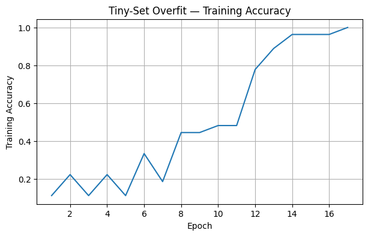

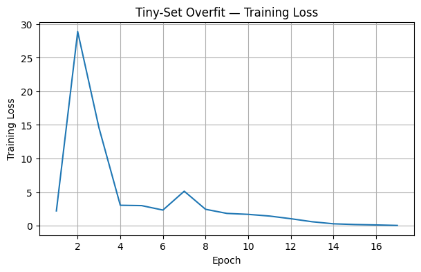

```python
# ==== Part (iii): Overfit a tiny dataset (memorization check) — with curves ====

import os, glob, time, torch
import torch.nn as nn
from torch.utils.data import Dataset, DataLoader
from PIL import Image
from torchvision import transforms
import matplotlib.pyplot as plt

# --- Tiny dataset
class TinyHandDataset(Dataset):
    def __init__(self, folder):
        self.paths = sorted(glob.glob(os.path.join(folder, "*.jpg")))
        assert len(self.paths) > 0, f"No .jpg files found in {folder}"
        labels = [os.path.basename(p).split("_")[1].upper() for p in self.paths]
        self.classes = sorted(set(labels))
        self.class_to_idx = {c:i for i,c in enumerate(self.classes)}
        self.y = [self.class_to_idx[l] for l in labels]
        # Images already 224x224; no resize needed
        self.tfms = transforms.Compose([transforms.ToTensor()])
    def __len__(self): return len(self.paths)
    def __getitem__(self, i):
        img = Image.open(self.paths[i]).convert("RGB")
        return self.tfms(img), self.y[i]

# --- Load tiny set
tiny_folder = "Zhao_1005843991_fixed"  # adjust if needed
tiny_ds = TinyHandDataset(tiny_folder)
print(f"Tiny dataset: {len(tiny_ds)} images, classes = {tiny_ds.classes}")

# --- Full-batch loader (one batch per epoch)
tiny_loader = DataLoader(tiny_ds, batch_size=len(tiny_ds), shuffle=True)

# --- Model
num_classes_tiny = len(tiny_ds.classes)
model = HandCNN(num_classes=num_classes_tiny)  # swap name if your class differs

# --- Training setup
device = torch.device("cuda" if torch.cuda.is_available() else "cpu")
model = model.to(device)
criterion = nn.CrossEntropyLoss()
optimizer = torch.optim.Adam(model.parameters(), lr=1e-2)  # if unstable, try 1e-3

# --- Train until 100% acc or 200 epochs; save checkpoints; collect metrics
os.makedirs("checkpoints_overfit", exist_ok=True)
best_acc = 0.0

# metrics_list will store tuples: (epoch, train_loss, train_acc)
metrics_list = []

for epoch in range(1, 201):
    model.train()
    epoch_loss_sum, epoch_correct, epoch_total = 0.0, 0, 0

    # one full batch per epoch
    for x, y in tiny_loader:
        x, y = x.to(device), y.to(device)
        optimizer.zero_grad()
        logits = model(x)
        loss = criterion(logits, y)
        loss.backward()
        optimizer.step()

        # accumulate epoch metrics
        epoch_loss_sum += loss.item() * x.size(0)
        epoch_correct  += (logits.argmax(1) == y).sum().item()
        epoch_total    += y.size(0)

    # epoch-level metrics
    train_loss = epoch_loss_sum / max(1, epoch_total)
    train_acc  = epoch_correct  / max(1, epoch_total)

    # collect for plotting
    metrics_list.append((epoch, train_loss, train_acc))

    # checkpoints
    if epoch % 20 == 0:
        torch.save(model.state_dict(), f"checkpoints_overfit/epoch_{epoch:03d}.pt")
    if train_acc > best_acc:
        best_acc = train_acc
        torch.save(model.state_dict(), "checkpoints_overfit/best.pt")

    print(f"Epoch {epoch:03d} | loss={train_loss:.4f} | train acc={train_acc*100:.1f}%")
    if train_acc == 1.0:
        print("✅ Reached 100% training accuracy (memorized the tiny dataset).")
        break

# --- Plot curves (Training Accuracy and Training Loss)
epochs     = [e for (e, _, _) in metrics_list]
train_loss = [l for (_, l, _) in metrics_list]
train_acc  = [a for (_, _, a) in metrics_list]

plt.figure(figsize=(7,4))
plt.plot(epochs, train_acc)
plt.xlabel("Epoch"); plt.ylabel("Training Accuracy")
plt.title("Tiny-Set Overfit — Training Accuracy")
plt.grid(True)
plt.show()

plt.figure(figsize=(7,4))
plt.plot(epochs, train_loss)
plt.xlabel("Epoch"); plt.ylabel("Training Loss")
plt.title("Tiny-Set Overfit — Training Loss")
plt.grid(True)
plt.show()
```